# Homework Problem 2

Dani Antos

September 24, 2017

Loading the zombie.csv file from Prof Schmitt’s GitHub

```r
library(curl)
f <- f <- curl("https://raw.githubusercontent.com/fuzzyatelin/fuzzyatelin.github.io/master/AN597_Fall17/zombies.csv")
d <- read.csv(f, header = TRUE, sep = ",", stringsAsFactors = FALSE)
head(d)
```

```
##   id first_name last_name gender   height   weight zombies_killed
## 1  1      Sarah    Little Female 62.88951 132.0872              2
## 2  2       Mark    Duncan   Male 67.80277 146.3753              5
## 3  3    Brandon     Perez   Male 72.12908 152.9370              1
## 4  4      Roger   Coleman   Male 66.78484 129.7418              5
## 5  5      Tammy    Powell Female 64.71832 132.4265              4
## 6  6    Anthony     Green   Male 71.24326 152.5246              1
##   years_of_education                           major      age
## 1                  1                medicine/nursing 17.64275
## 2                  3 criminal justice administration 22.58951
## 3                  1                       education 21.91276
## 4                  6                  energy studies 18.19058
## 5                  3                       logistics 21.10399
## 6                  4                  energy studies 21.48355
```

# Question 1

Calculating population means and standard deviations is not the same as the sample mean and sd. This was part of Module 7. Wait, maybe the mean would be the same? It’s just the variance and SD that are different?

Height:

```r
mean(d$height)
```

```
## [1] 67.6301
```

```r
h <- sum((d$height-mean(d$height))^2)/length(d$height)
sqrt(h)
```

```
## [1] 4.30797
```

Weight:

```r
mean(d$weight)
```

```
## [1] 143.9075
```

```r
w <- sum((d$weight-mean(d$weight))^2)/length(d$weight)
sqrt(w)
```

```
## [1] 18.39186
```

Age:

```r
mean(d$age)
```

```
## [1] 20.04696
```

```r
a <- sum((d$age-mean(d$age))^2)/length(d$age)
sqrt(a)
```

```
## [1] 2.963583
```

Number of zombied killed:

```r
mean(d$zombies_killed)
```

```
## [1] 2.992
```

```r
z <- sum((d$zombies_killed-mean(d$zombies_killed))^2)/length(d$zombies_killed)
sqrt(z)
```

```
## [1] 1.747551
```

Years of education:

```r
mean(d$years_of_education)
```

```
## [1] 2.996
```

```r
e <- sum((d$years_of_education-mean(d$years_of_education))^2)/length(d$years_of_education)
sqrt(e)
```

```
## [1] 1.675704
```

# Question 2

Height:

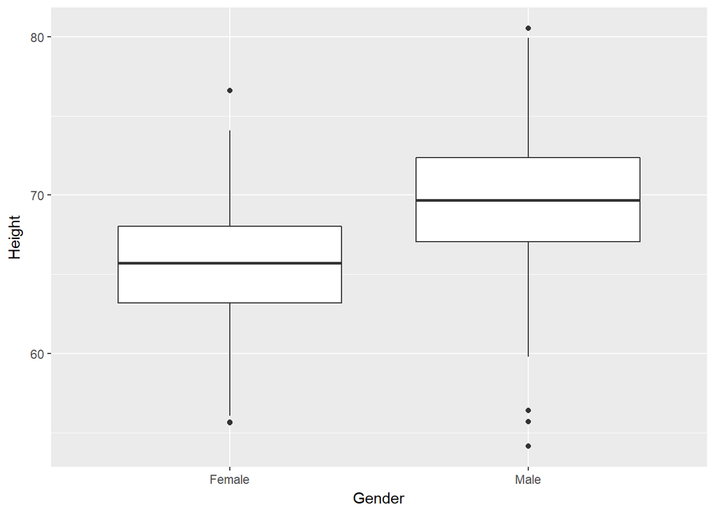

```r
library(ggplot2)
p <- ggplot(data=d, aes(x= gender, y= height))
p <- p +geom_boxplot()
p <- p + xlab("Gender") + ylab("Height")
p
```

Weight:

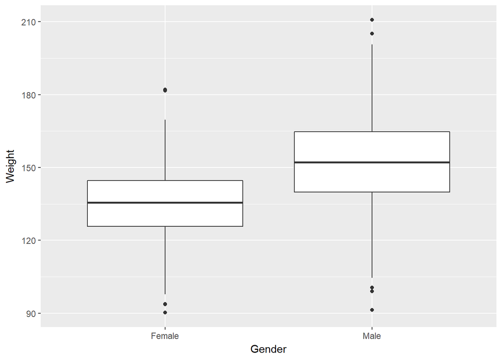

```r
library(ggplot2)
m <- ggplot(data=d, aes(x= gender, y= weight))
m <- m +geom_boxplot()
m <- m + xlab("Gender") + ylab("Weight")
m
```

Age:

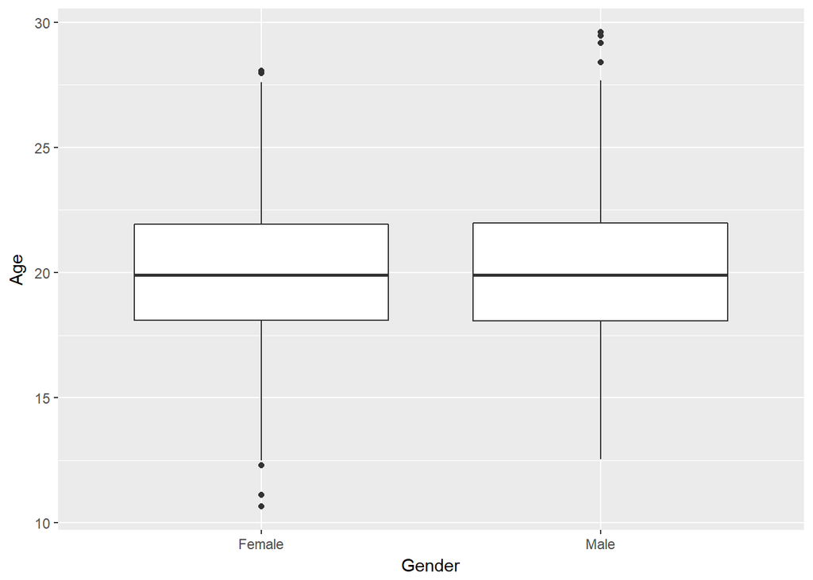

```r
library(ggplot2)
q <- ggplot(data=d, aes(x= gender, y= age))
q <- q +geom_boxplot()
q <- q +xlab("Gender") + ylab("Age")
q
```

Number of zombies killed:

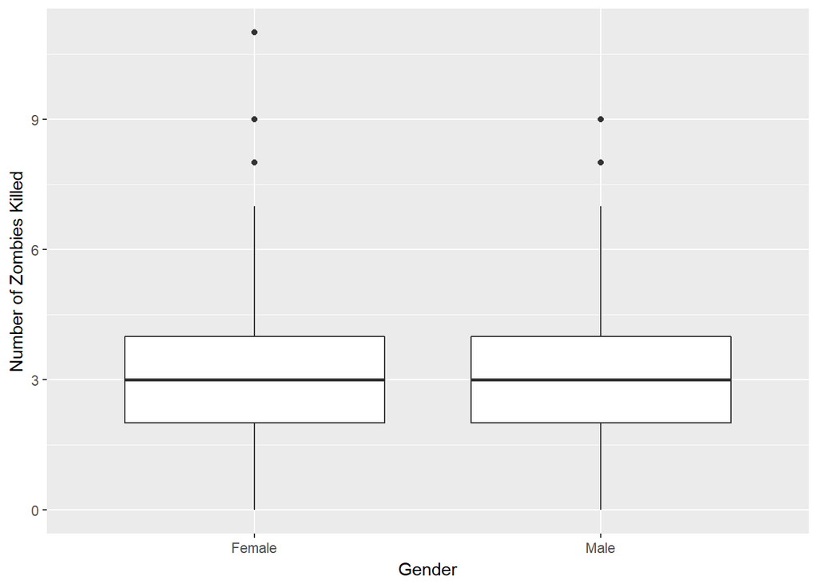

```r
library(ggplot2)
b <- ggplot(data=d, aes(x= gender, y= zombies_killed))
b <- b +geom_boxplot()
b <- b + xlab("Gender") + ylab("Number of Zombies Killed")
b
```

Years of education:

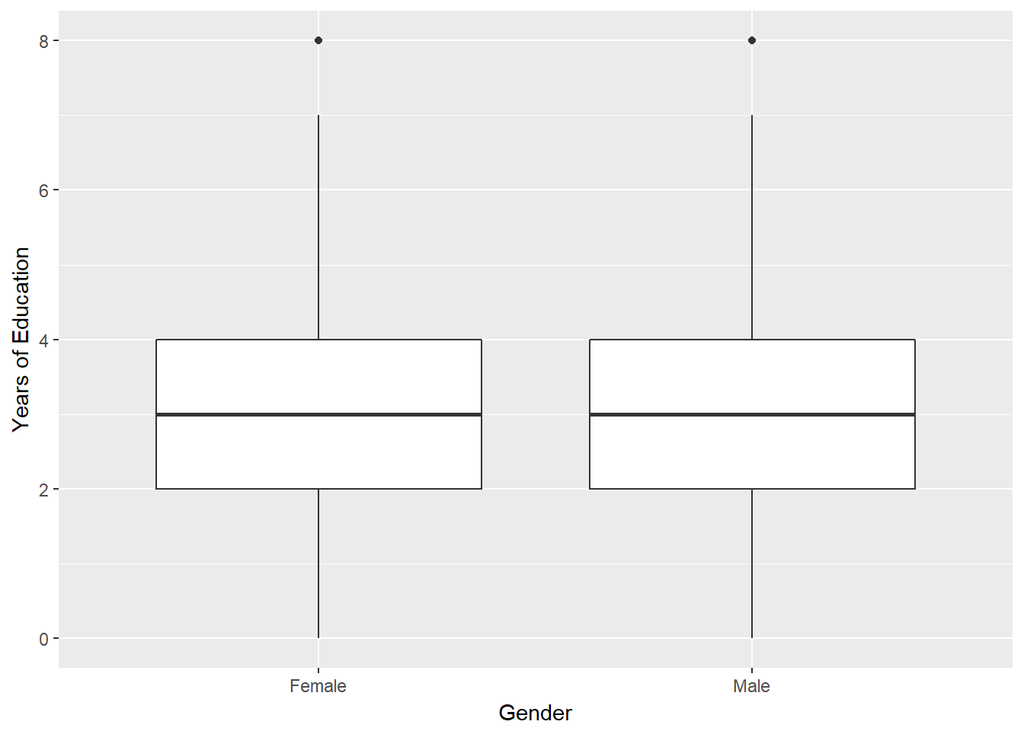

```r
library(ggplot2)
c <- ggplot(data=d, aes(x= gender, y= years_of_education))
c <- c +geom_boxplot()
c <- c + xlab("Gender") + ylab("Years of Education")
c
```

# Question 3

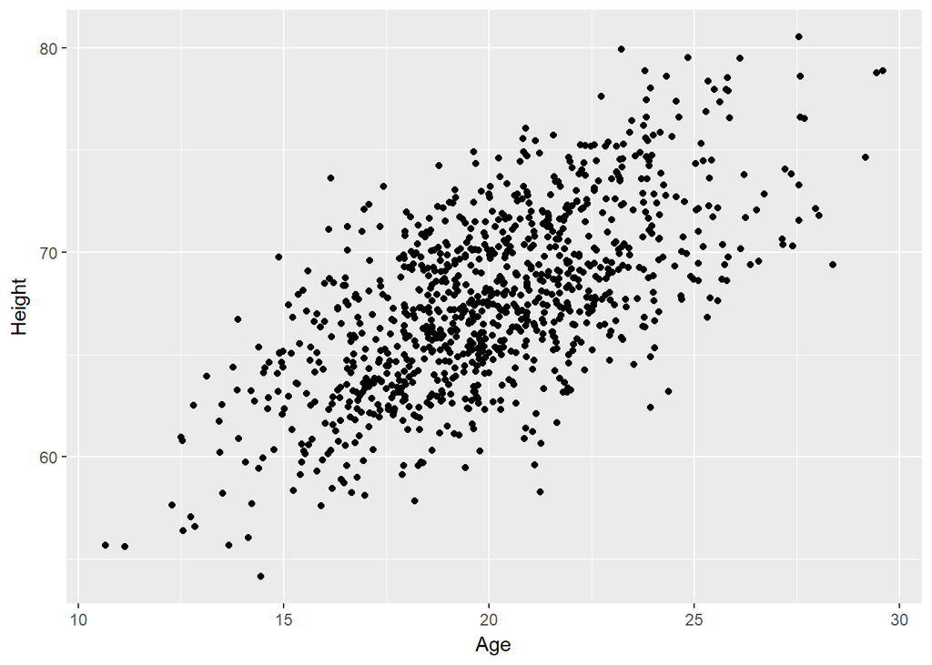

```r
library(ggplot2)
p <- ggplot(data=d, aes(x= age, y= height))
p <- p +xlab("Age") + ylab("Height")
p <- p + geom_point()
p
```

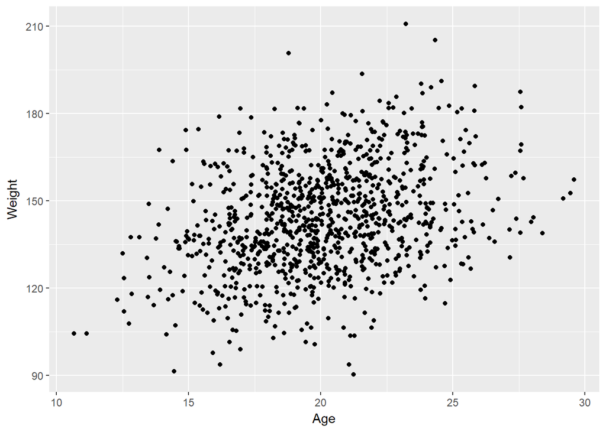

```r
library(ggplot2)
q <- ggplot(data=d, aes(x= age, y= weight))
q <- q +xlab("Age") + ylab("Weight")
q <- q + geom_point()
q
```

Both height and weight seem to have a positive correlation with age. Height seems to have a stronger correlation with age than weight does just by looking at the two graphs.

# Question 4

Age:

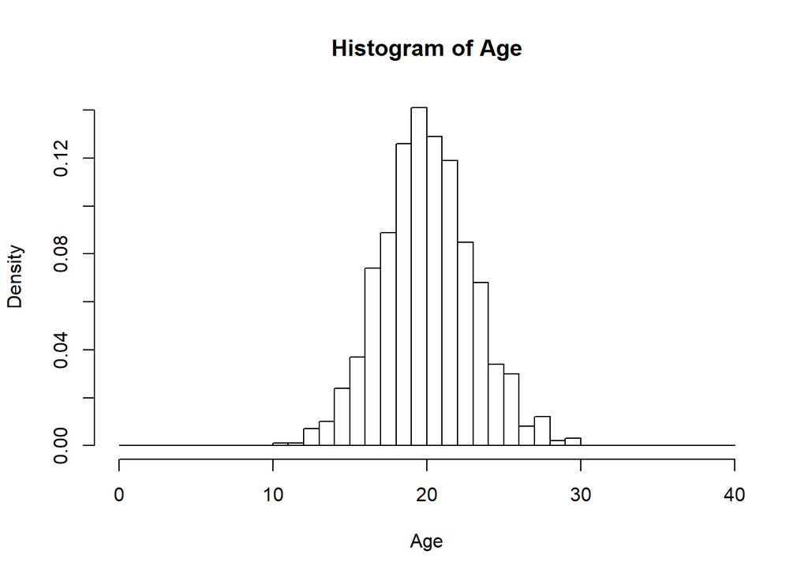

```r
hist(d$age, breaks= seq(0, 40, 1), probability=TRUE, main="Histogram of Age", xlab="Age")
```

That gives me the histogram for the ages of the zombie survivors.

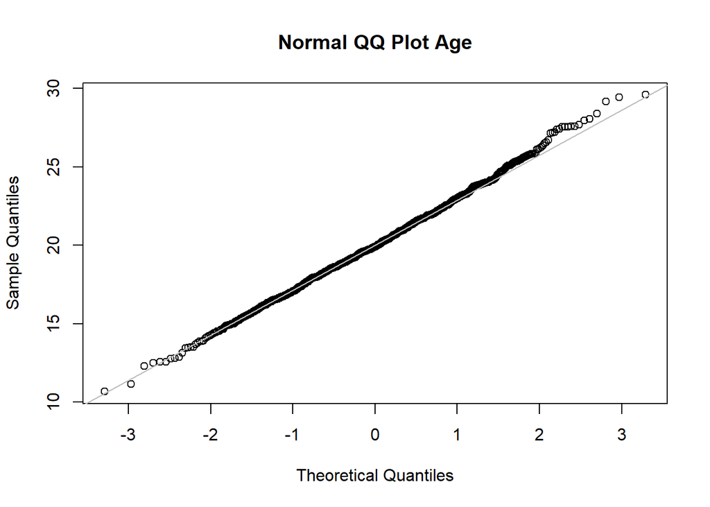

```r
qqnorm(d$age, main= "Normal QQ Plot Age")
qqline(d$age, col="gray")
```

Age seems to follow a normal distribution.

Height:

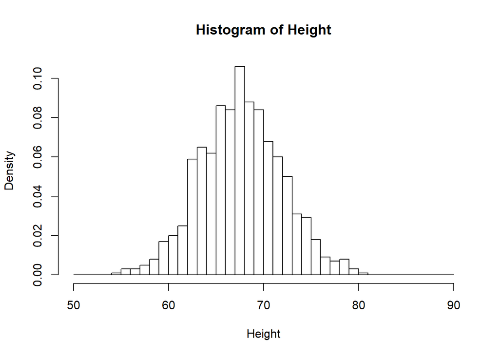

```r
hist(d$height, breaks= seq(50, 90, 1), probability=TRUE, main="Histogram of Height", xlab="Height")
```

To be honest, I wasn’t sure what to set the “by” argument as because each height is rounded to four decimal places but that histogram looked like a hot mess.

[figure not shown]

```r
qqnorm(d$age, main= "Normal QQ Plot Height")
qqline(d$age, col="gray")
```

Height also appears to follow a normal distribution.

Weight:

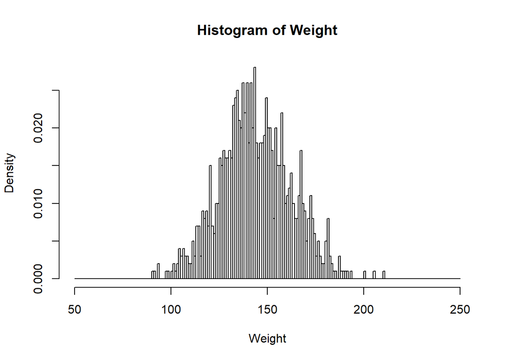

```r
hist(d$weight, breaks= seq(50, 250, 1), probability=TRUE, main="Histogram of Weight", xlab="Weight")
```

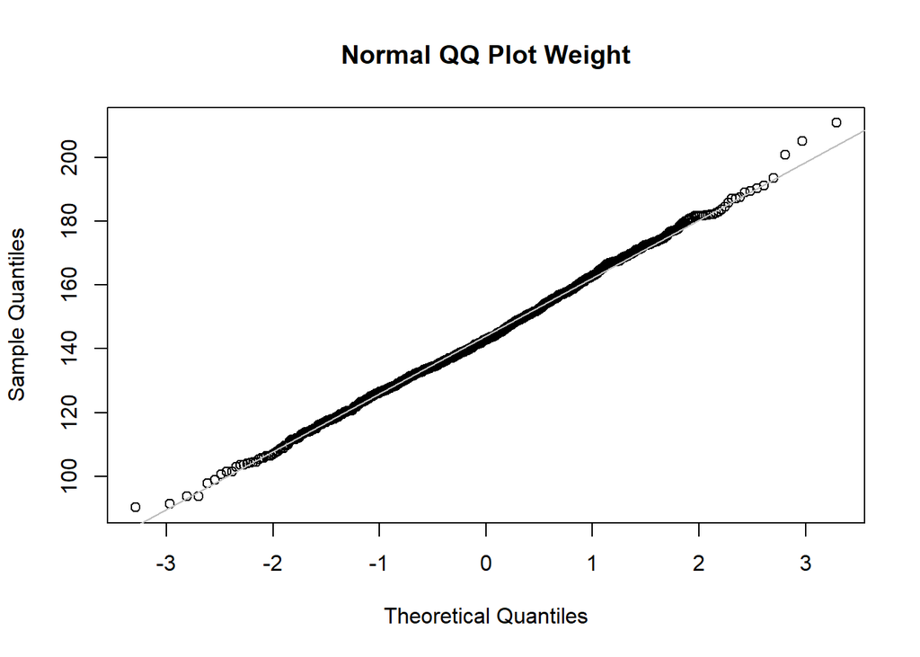

```r
qqnorm(d$weight, main="Normal QQ Plot Weight")
qqline(d$weight, col="gray")
```

Weight appears to follow a normal distribution. (Am I doing this right?)

Number of Zombies Killed:

**NOTE:** Instructions for this portion made it unclear to me whether we are supposed to be proving that it is a certain (in this case Poisson) distribution or just proving that it isn’t following a normal distribution. Replacing “qpois” with “qnorm” would prove the latter.

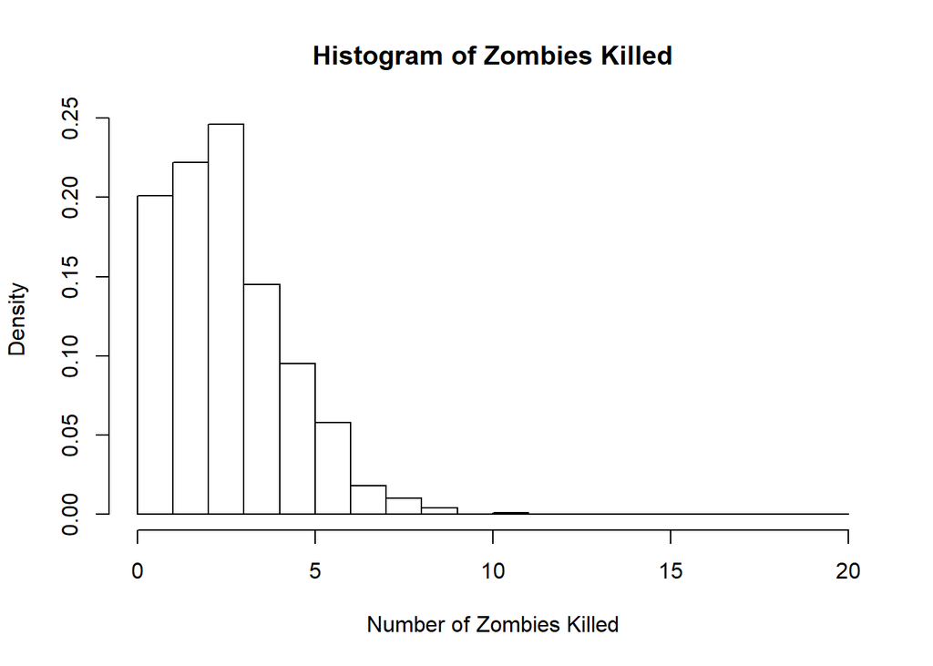

```r
hist(d$zombies_killed, breaks= seq(0, 20, 1), probability = TRUE, main= "Histogram of Zombies Killed", xlab="Number of Zombies Killed")
```

This looks like a Poisson distribution, but I need to confirm that.

```r
p <- ppoints(length(d$zombies_killed))
head(p)
```

```
## [1] 0.0005 0.0015 0.0025 0.0035 0.0045 0.0055
```

```r
tail(p) #step one from module 8
```

```
## [1] 0.9945 0.9955 0.9965 0.9975 0.9985 0.9995
```

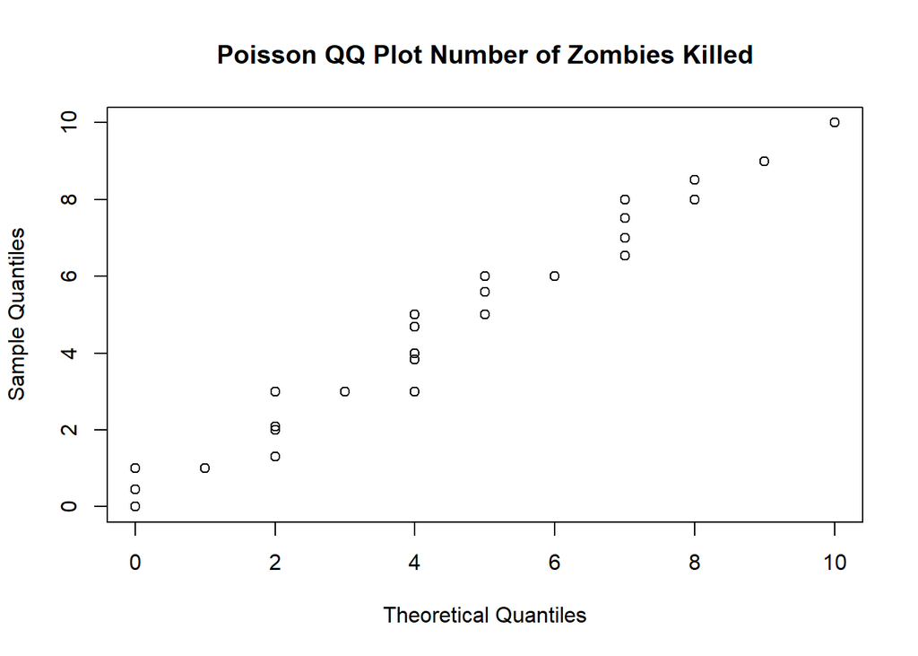

```r
theoretical_q<- qpois(ppoints(length(d$zombies_killed)), mean(d$zombies_killed)) #step 2 to get theoretical values
observed_q <- quantile(d$zombies_killed, ppoints(d$zombies_killed)) #step 3 to get quantiles of observed data
plot(theoretical_q, observed_q, main="Poisson QQ Plot Number of Zombies Killed", xlab="Theoretical Quantiles", ylab="Sample Quantiles")
```

Well that looks like a relatively straight line, but it looks much different than the other Q-Q plots, but I’d still say the Number of Zombies Killed follows a Poisson distribution, which I think also makes sense because we’re counting.

Years of Education:

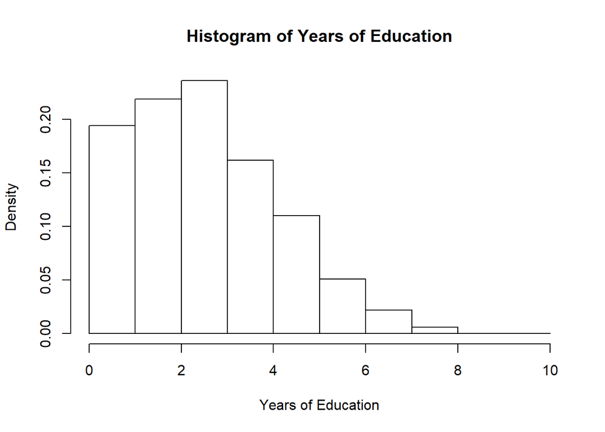

```r
hist(d$years_of_education, breaks= seq(0, 10, 1), probability=TRUE, main= "Histogram of Years of Education", xlab="Years of Education")
```

Okay again I’m thinking Poisson, which would make sense again because we’re counting.

```r
p <- ppoints(length(d$years_of_education))
head(p)
```

```
## [1] 0.0005 0.0015 0.0025 0.0035 0.0045 0.0055
```

```r
tail(p)
```

```
## [1] 0.9945 0.9955 0.9965 0.9975 0.9985 0.9995
```

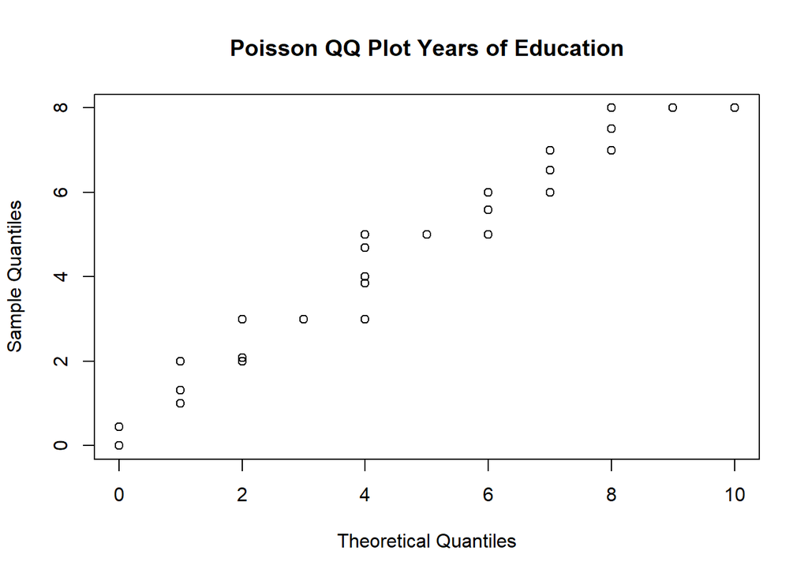

```r
theoretical_q<- qpois(ppoints(length(d$years_of_education)), mean(d$years_of_education))
observed_q <- quantile(d$years_of_education, ppoints(d$years_of_education))
plot(theoretical_q, observed_q, main="Poisson QQ Plot Years of Education", xlab="Theoretical Quantiles", ylab="Sample Quantiles")
```

Again, it looks like a straight line but there are was fewer points than on the Q-Q plots for the normal distributions. But it looks like Years of Education follows a Poisson distribution.

# Question 5

```r
library(dplyr)
subset_1 <- sample_n(d, 30, replace=FALSE, weight=NULL, .env=NULL)
subset_1
```

```
##      id first_name  last_name gender   height   weight zombies_killed
## 738 738      Kathy    Jenkins Female 64.74725 134.3241              4
## 761 761     Sharon      Allen Female 61.31970 136.3508              3
## 97   97       Ryan      Davis   Male 65.05317 133.1287              2
## 324 324      Craig    Stewart   Male 67.42625 161.5173              4
## 942 942      Susan  Patterson Female 64.67957 134.2557              3
## 8     8    Phyllis    Jenkins Female 59.82760 108.8093              4
## 535 535     Amanda     Rogers Female 63.27210 108.8833              3
## 449 449     Jeremy      Riley   Male 64.90341 132.8371              2
## 544 544     Andrew   Mitchell   Male 76.61531 170.6254              3
## 806 806       Lori     Flores Female 62.67853 136.8445              2
## 755 755      Tammy   Anderson Female 66.13981 125.8349              4
## 517 517      Kathy     Fuller Female 63.64877 133.9467              2
## 765 765    Carolyn     Tucker Female 58.35161 114.9680              3
## 338 338   Kathleen     Carter Female 67.32688 134.0057              5
```

[output cut: 47 more lines]

So now that I’m working with a sample (rather than the whole population), I think that I can use the built in functions for mean and standard deviation. (I originally did the code in the order that the homework listed them, but rearranged them by variable because I thought it looked better) sample size=30

Age:

```r
m <- mean(subset_1$age)
m
```

```
## [1] 18.98723
```

```r
s <- sd(subset_1$age)
s
```

```
## [1] 2.981805
```

```r
error <- sd(subset_1$age)/sqrt(30)
error
```

```
## [1] 0.5444006
```

```r
#age has a normal distribution so I can use qnorm()
upper <- qnorm(0.975, mean=m, sd=s)
lower <- qnorm(0.025, mean=m, sd=s)
ci <- c(lower, upper)
ci
```

```
## [1] 13.14300 24.83146
```

Height:

```r
m <- mean(subset_1$height)
m
```

```
## [1] 65.56953
```

```r
s <- sd(subset_1$height)
s
```

```
## [1] 4.271414
```

```r
error <- sd(subset_1$height)/sqrt(30)
error
```

```
## [1] 0.7798499
```

```r
#height has a normal distribution
upper <- qnorm(0.975, mean=m, sd=s)
lower <- qnorm(0.025, mean=m, sd=s)
ci <- c(lower, upper)
ci
```

```
## [1] 57.19771 73.94135
```

Weight:

```r
m <-mean(subset_1$weight)
m
```

```
## [1] 137.561
```

```r
s <- sd(subset_1$weight)
s
```

```
## [1] 16.7728
```

```r
error <- sd(subset_1$weight)/sqrt(30)
error
```

```
## [1] 3.06228
```

```r
#weight has a normal distribution
upper <- qnorm(0.975, mean=m, sd=s)
lower <- qnorm(0.025, mean=m, sd=s)
ci <- c(lower, upper)
ci
```

```
## [1] 104.6869 170.4351
```

Number of Zombies Killed: (I know that this is going to be different from the variables above because it follows a different distribution)

```r
m <- mean(subset_1$zombies_killed)
m
```

```
## [1] 3
```

```r
s <- sd(subset_1$zombies_killed)
s
```

```
## [1] 1.17444
```

```r
error <- sd(subset_1$zombies_killed)/sqrt(30)
error
```

```
## [1] 0.2144225
```

```r
upper <- qpois(0.975, m)
lower <- qpois(0.025, m)
ci <- c(lower, upper)
ci #lower is 0, which makes sense to me because you can't kill negative zombies
```

```
## [1] 0 7
```

Years of Education: (also Poisson distribution)

```r
m <- mean(subset_1$years_of_education)
m
```

```
## [1] 2.4
```

```r
s <- sd(subset_1$years_of_education)
error <- sd(subset_1$years_of_education)/sqrt(30)
error
```

```
## [1] 0.3092445
```

```r
upper <- qpois(0.975, m)
lower <- qpois(0.025, m)
ci <- c(lower, upper)
ci
```

```
## [1] 0 6
```

# Question 6

Okay not gonna lie, I’m struggling a little bit conceptually here but I took notes on how you verbally explained this in class. So “subset of n” would be 30 because I want each subset to contain 30 rows, but I think I have to do each variable separately because r would try to take the mean of multiple variables and/or non-integer values. Then “x” would be 99 because we want to take subsets 99 times (for a total of 100 subsets including the one I created in **Question 5**).

So this is the code from Module 7: set <- NULL n <- 15 for (i in 1:10000) { set[i] <- mean(sample(x, n, replace = TRUE)) }

and to my understanding, n=30, instead of 1:10000 it would be 1:99, and x would just be whatever variable I’m working with.

**Hi just a note, I know that something is wrong here because none of my standard deviations from this problem are even close to my standard errors from number 5, but I’m not sure what I did/how to fix it. I’m just hoping you won’t be too harsh on me because I did realise that something was wrong :)** Age:

```r
set <- NULL
n <- 30
for (i in 1:99) {
    set[i] <- mean(sample(d$age, n, replace = FALSE))
}
set
```

```
##  [1] 20.60912 20.45732 20.97633 19.82360 18.99921 18.81776 19.94142
##  [8] 19.71903 20.86350 20.77865 19.75466 19.90085 20.15158 20.71917
## [15] 19.71521 19.37794 19.19038 19.18856 20.56915 20.42489 19.43595
## [22] 20.07346 19.99740 19.65879 19.97922 20.60953 19.75721 19.70427
## [29] 20.27333 19.91097 20.17233 19.92792 20.46963 20.38191 19.37527
## [36] 20.03250 20.49710 19.82982 19.46456 19.50998 21.40740 20.42751
## [43] 20.33357 19.71537 19.52271 20.85746 19.22713 20.32905 19.79568
## [50] 21.04034 20.05585 19.73385 20.13309 19.14791 20.37377 20.59432
## [57] 19.64063 19.33950 20.45107 20.51117 19.77333 20.80713 20.36806
## [64] 19.27935 19.12872 20.82358 20.56110 19.65237 18.97098 19.16077
## [71] 20.66185 19.15385 19.56724 20.13582 20.78674 20.27373 19.89998
## [78] 19.55494 19.57103 19.50666 19.79940 20.18922 20.50862 19.60264
## [85] 20.40414 19.67528 19.55873 20.53748 19.16815 20.75661 19.87073
## [92] 19.35248 19.90346 20.89901 18.84444 19.61723 20.29677 19.98105
## [99] 20.09238
```

Okay, now to my understanding, this function’s output will be 99 means of 30 ages each. I’m still a little unsure as to how to integrate this data with the last (100th) mean that I already computed. Also, wording is a bit confusing here, do you want me to take the mean of the 100 means? I guess that would make the most sense..

```r
v <- c(set, subset_1$age)
mean(v)
```

```
## [1] 19.75185
```

```r
sd(v)
```

```
## [1] 1.561541
```

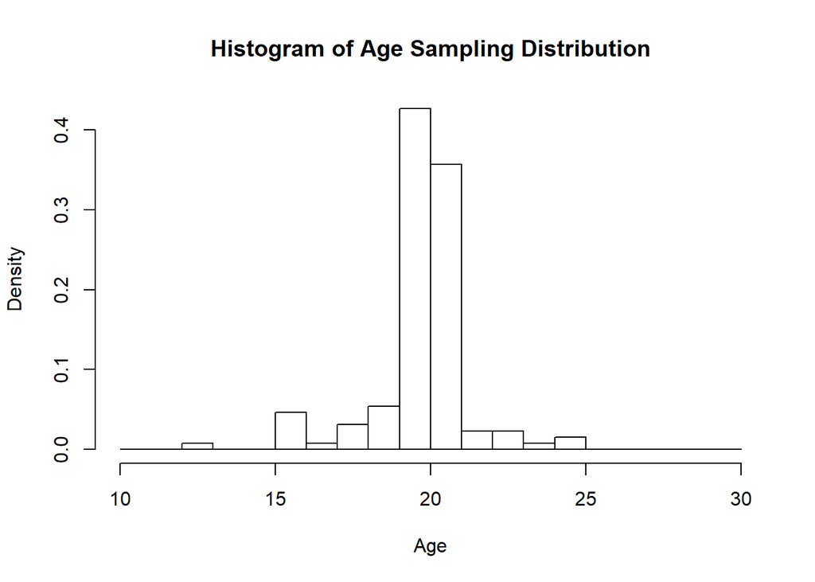

```r
#sd is larger than error from question 5 which makes me think I did something wrong, but this sd is much smaller than the sd from number 5
hist(v, breaks= seq(10, 30, 1), probability=TRUE, main= "Histogram of Age Sampling Distribution", xlab="Age")
```

Now I have to repeat for each variable and I’m finding it highly doubtful this is the easiest way to accomplish this task.

Height:

```r
set <- NULL
n <- 30
for (i in 1:99) {
    set[i] <- mean(sample(d$height, n, replace = FALSE))
}
set
```

```
##  [1] 68.19840 67.67463 66.21269 67.91624 68.36638 67.70668 67.61120
##  [8] 67.51948 67.17494 67.00667 65.36404 67.12033 67.77727 66.06075
## [15] 67.82541 67.35434 66.59131 66.27047 66.49855 67.08400 67.47429
## [22] 67.68025 68.42395 68.30541 66.81476 68.42354 68.29768 68.32615
## [29] 67.36555 67.97752 68.03330 66.94471 66.64990 67.09617 67.35175
## [36] 67.64946 68.04544 66.03865 66.08414 66.69241 68.04154 67.97913
## [43] 67.80714 67.28114 66.38245 68.76204 68.50799 68.29914 67.93029
## [50] 68.58342 67.58237 66.21122 67.66845 67.33761 66.72836 67.12506
## [57] 65.78365 68.56182 66.81579 66.75025 67.19719 67.03355 68.08674
## [64] 67.47337 66.40863 67.81782 67.92278 69.03069 67.33412 67.17385
## [71] 68.13325 67.95928 67.34386 68.04001 67.25567 68.73487 67.53211
## [78] 67.86698 67.60862 67.70573 67.57355 69.30133 67.37704 67.56152
## [85] 67.80759 67.47779 67.48570 67.00423 66.54632 67.22654 68.34777
## [92] 68.40956 67.73172 68.41390 66.86804 68.46347 67.22711 69.21159
## [99] 68.18082
```

```r
v <- c(set, subset_1$height)
mean(v)
```

```
## [1] 67.07061
```

```r
sd(v)
```

```
## [1] 2.297021
```

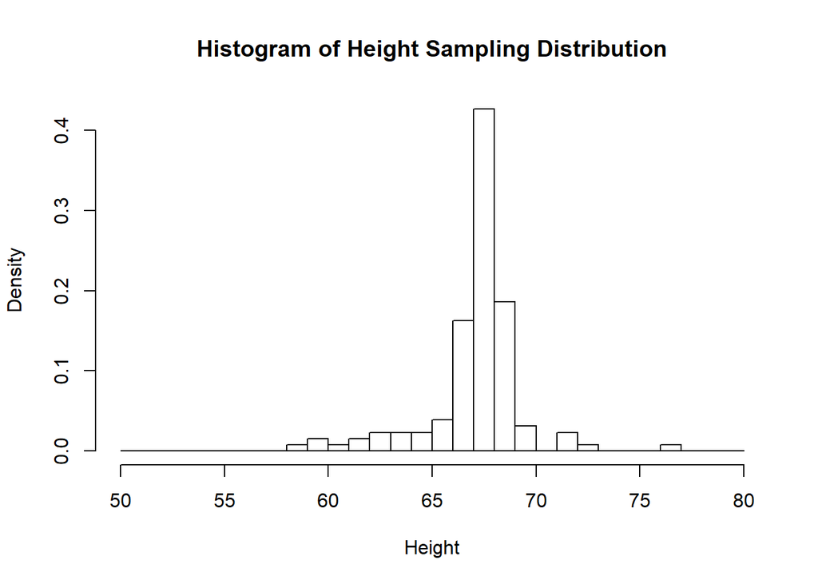

```r
#again, sd is greater than the error calculated in question 5
hist(v, breaks= seq(50, 80, 1), probability=TRUE, main= "Histogram of Height Sampling Distribution", xlab="Height")
```

Weight:

```r
set <- NULL
n <- 30
for (i in 1:99) {
    set[i] <- mean(sample(d$weight, n, replace = FALSE))
}
set
```

```
##  [1] 140.2210 144.8491 146.0475 144.3780 144.6177 144.7736 147.1626
##  [8] 144.4886 145.7364 139.5748 144.8932 139.5006 142.3372 141.9834
## [15] 141.2772 140.2206 147.1320 144.6447 140.1333 145.6693 141.9944
## [22] 141.5185 146.0497 145.4546 139.0444 143.1239 147.1651 144.9566
## [29] 143.5047 144.1936 147.6164 140.9097 146.7268 144.0400 143.9680
## [36] 148.0954 141.7156 144.0044 147.6207 141.4008 146.7865 143.2344
## [43] 150.9662 140.4923 145.4716 150.0711 140.0685 140.7853 149.3816
## [50] 146.4777 141.5646 149.5133 142.6212 144.7619 144.6882 139.0944
## [57] 147.4207 144.8027 145.0053 141.6439 145.8768 140.9885 151.0010
## [64] 144.1901 143.7032 145.8503 146.9898 140.8804 140.9111 141.9196
## [71] 144.4955 137.9237 146.8646 142.9122 145.1532 143.9249 141.8206
## [78] 144.2881 146.0792 141.4052 143.6819 141.3602 153.7675 144.3524
## [85] 137.8960 147.1458 151.3441 142.0913 141.4517 144.9183 145.4722
## [92] 144.2432 146.2278 143.7414 145.5100 137.4980 145.5506 142.4237
## [99] 139.5539
```

```r
v <- c(set, subset_1$weight)
mean(v)
```

```
## [1] 142.5569
```

```r
sd(v)
```

```
## [1] 8.879947
```

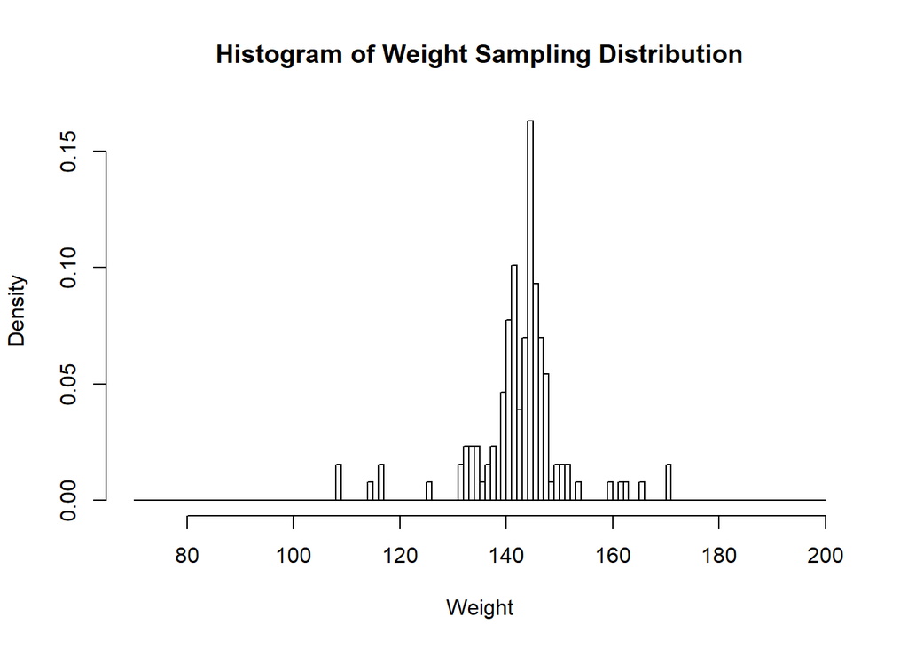

```r
#sd here is greater than the error calculated in question 5, but less than the sd from question 5
hist(v, breaks= seq(70, 200, 1), probability=TRUE, main= "Histogram of Weight Sampling Distribution", xlab="Weight")
```

Number of Zombies Killed:

```r
set <- NULL
n <- 30
for (i in 1:99) {
    set[i] <- mean(sample(d$zombies_killed, n, replace =FALSE))
}
set
```

```
##  [1] 3.266667 2.933333 2.933333 3.033333 3.266667 2.666667 2.733333
##  [8] 3.533333 3.033333 3.000000 2.466667 3.166667 2.833333 2.733333
## [15] 3.266667 3.233333 2.900000 2.700000 3.033333 2.933333 3.133333
## [22] 2.700000 3.133333 3.333333 3.100000 3.000000 2.800000 3.266667
## [29] 2.466667 3.200000 3.066667 3.133333 2.900000 2.666667 3.266667
## [36] 3.233333 3.000000 2.300000 3.066667 3.200000 3.200000 3.000000
## [43] 3.100000 2.800000 2.633333 2.933333 3.200000 2.966667 2.833333
## [50] 2.833333 2.666667 2.966667 2.866667 2.800000 3.200000 2.600000
## [57] 2.966667 2.733333 3.266667 2.733333 3.766667 2.833333 3.300000
## [64] 3.133333 3.100000 2.300000 2.666667 2.900000 3.233333 3.500000
## [71] 2.733333 2.600000 2.866667 2.733333 2.666667 3.466667 2.300000
## [78] 3.566667 2.733333 2.733333 3.166667 3.166667 2.633333 2.866667
## [85] 3.833333 3.400000 2.866667 2.566667 3.033333 3.066667 2.766667
## [92] 3.400000 3.133333 2.933333 2.733333 3.266667 2.400000 2.900000
## [99] 3.033333
```

```r
v <- c(set, subset_1$zombies_killed)
mean(v)
```

```
## [1] 2.978553
```

```r
sd(v)
```

```
## [1] 0.6179154
```

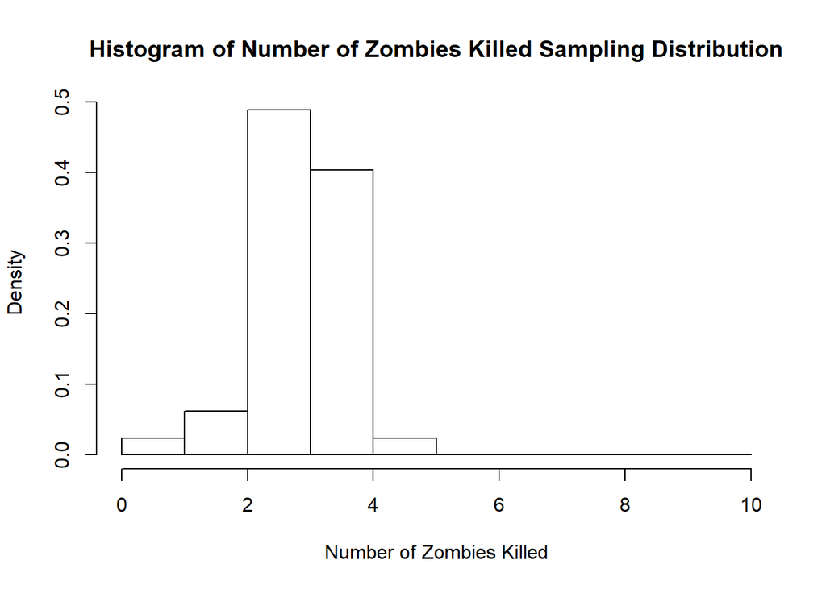

```r
#sd here is greater than the error calculated in question 5
hist(v, breaks= seq(0, 10, 1), probability=TRUE, main= "Histogram of Number of Zombies Killed Sampling Distribution", xlab= "Number of Zombies Killed")
```

Looks more like a normal distribution than a Poisson distribution.

```r
p <- ppoints(length(v))
head(p)
```

```
## [1] 0.003875969 0.011627907 0.019379845 0.027131783 0.034883721 0.042635659
```

```r
tail(p)
```

```
## [1] 0.9573643 0.9651163 0.9728682 0.9806202 0.9883721 0.9961240
```

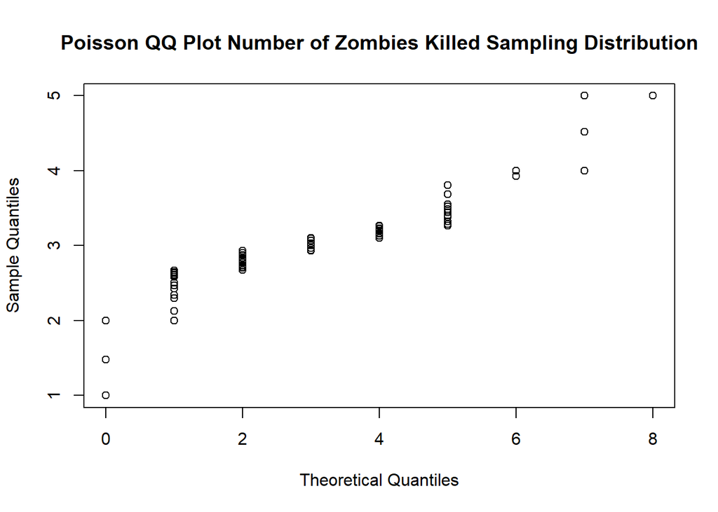

```r
theoretical_q<- qpois(ppoints(length(v)), mean(v))
observed_q <- quantile(v, ppoints(v))
plot(theoretical_q, observed_q, main="Poisson QQ Plot Number of Zombies Killed Sampling Distribution", xlab="Theoretical Quantiles", ylab="Sample Quantiles")
```

Years of Education:

```r
set <- NULL
n <- 30
for (i in 1:99) {
    set[i] <- mean(sample(d$years_of_education, n, replace = FALSE))
}
set
```

```
##  [1] 3.266667 2.200000 3.200000 2.466667 2.833333 2.733333 3.133333
##  [8] 3.466667 3.466667 2.966667 2.933333 3.033333 3.200000 2.500000
## [15] 3.166667 3.300000 2.800000 3.000000 3.466667 3.000000 3.100000
## [22] 3.000000 2.633333 2.766667 2.833333 3.133333 3.400000 2.600000
## [29] 3.500000 2.666667 3.033333 3.166667 3.533333 3.400000 2.866667
## [36] 3.066667 2.600000 2.600000 3.233333 2.733333 3.133333 3.100000
## [43] 2.566667 3.400000 2.133333 3.433333 3.333333 3.766667 3.100000
## [50] 2.900000 3.033333 2.300000 3.000000 3.633333 2.800000 3.300000
## [57] 3.333333 2.700000 3.266667 3.233333 2.533333 2.900000 3.233333
## [64] 3.333333 2.733333 3.100000 3.066667 3.133333 3.000000 2.966667
## [71] 3.300000 2.866667 2.233333 2.500000 2.833333 3.066667 3.333333
## [78] 2.766667 3.500000 3.133333 3.466667 2.566667 2.966667 3.266667
## [85] 3.300000 2.966667 2.766667 2.933333 2.766667 3.066667 2.800000
## [92] 2.466667 3.066667 3.466667 2.666667 2.600000 2.600000 2.533333
## [99] 2.800000
```

```r
v <- c(set, subset_1$years_of_education)
mean(v)
```

```
## [1] 2.85323
```

```r
sd(v)
```

```
## [1] 0.8951307
```

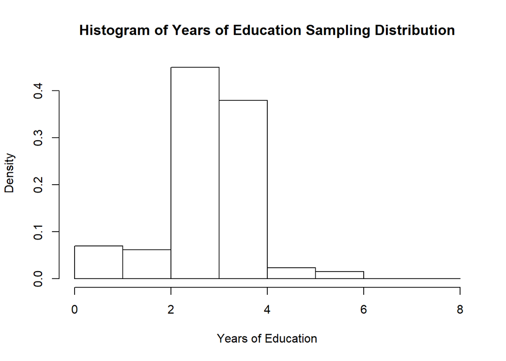

```r
#sd is greater than error from question 5
hist(v, breaks= seq(0, 8, 1), probability=TRUE, main= "Histogram of Years of Education Sampling Distribution", xlab= "Years of Education")
```

Like “zombies killed,” years of education previously had a Poisson distribution. Now it looks more like a normal distribution because the highest peaks aren’t where I would expect them to be for a Poisson.

```r
p <- ppoints(length(v))
head(p)
```

```
## [1] 0.003875969 0.011627907 0.019379845 0.027131783 0.034883721 0.042635659
```

```r
tail(p)
```

```
## [1] 0.9573643 0.9651163 0.9728682 0.9806202 0.9883721 0.9961240
```

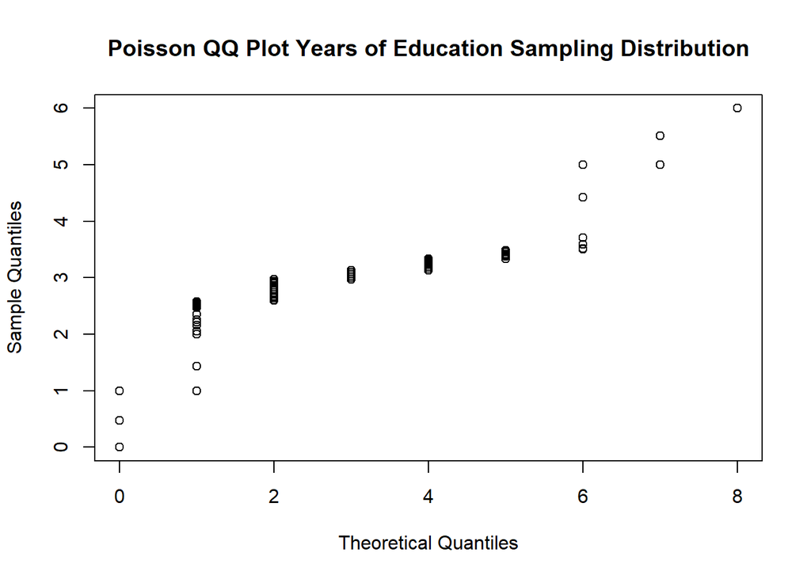

```r
theoretical_q<- qpois(ppoints(length(v)), mean(v))
observed_q <- quantile(v, ppoints(v))
plot(theoretical_q, observed_q, main="Poisson QQ Plot Years of Education Sampling Distribution", xlab="Theoretical Quantiles", ylab="Sample Quantiles")
```

It doesn’t look very straight, so I’m thinking that it’s more of a normal distribution.